# 2024 NH3-loss Statistical Models, outdoor only - cube root

## Model A_Cover

```
##    Cover   N
## 1   None 360
## 2 Arable 713
## 3  Grass 320
## 4  Other  18
```

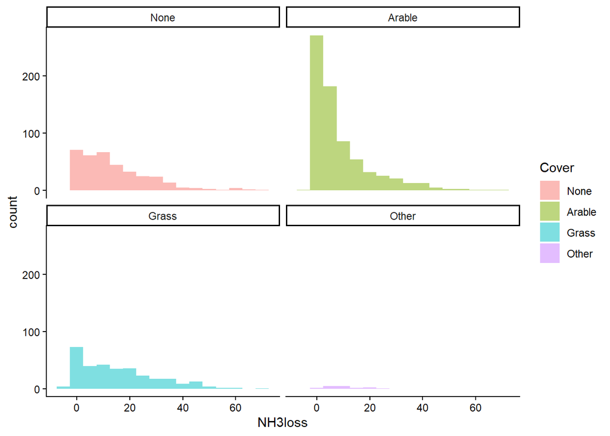

We added Cover as a fixed factor and a sole explanatory variable in the model.

```r
# Model
m6_lm <- lm(sign(NH3loss) * abs(NH3loss) ^ (1/3) ~ Cover + offset(M1_fit),
            weights=Weight,
            data=NH3predict_m6)
```

The model assumptions (heteroscedasticity and normality of errors):

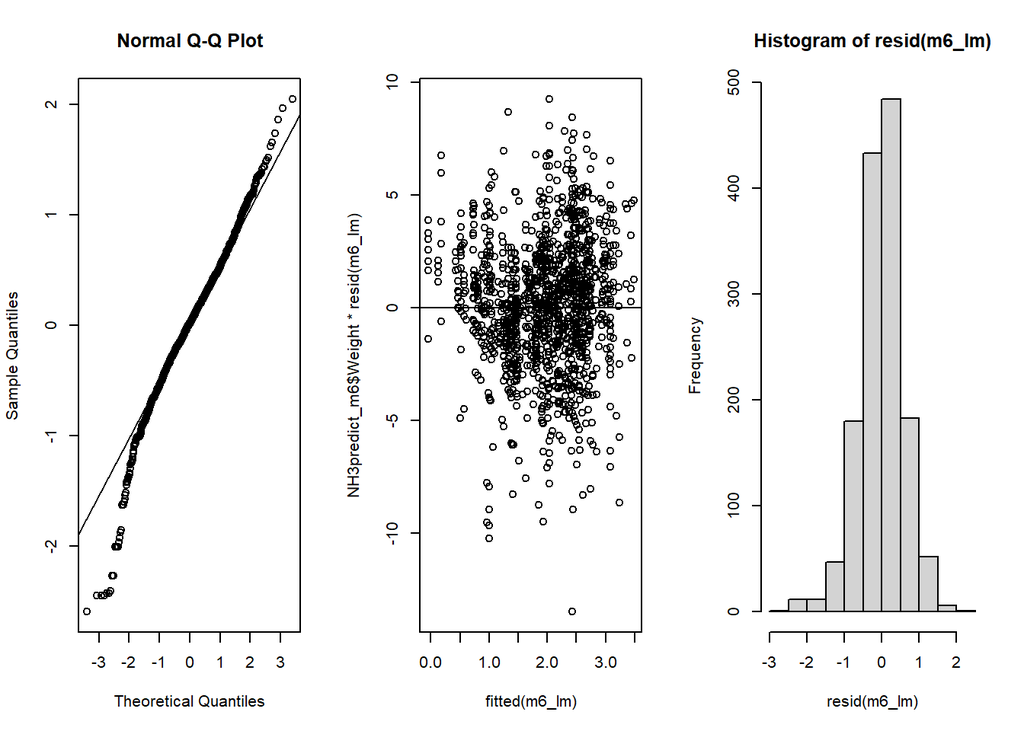

Full model output can be seen below:

```
##
## Call:
## lm(formula = sign(NH3loss) * abs(NH3loss)^(1/3) ~ Cover + offset(M1_fit),
##     data = NH3predict_m6, weights = Weight)
##
## Weighted Residuals:
##     Min      1Q  Median      3Q     Max
## -5.7179 -0.7441  0.0286  0.8219  4.2092
##
## Coefficients:
##             Estimate Std. Error t value Pr(>|t|)
## (Intercept)  0.03147    0.03036   1.036    0.300
## CoverArable -0.05592    0.03784  -1.478    0.140
## CoverGrass  -0.01529    0.04413  -0.347    0.729
## CoverOther  -0.06849    0.14014  -0.489    0.625
##
## Residual standard error: 1.312 on 1407 degrees of freedom
## Multiple R-squared:  0.001827,   Adjusted R-squared:  -0.0003018
## F-statistic: 0.8582 on 3 and 1407 DF,  p-value: 0.4622
```

Adjusted R2-value of the model was -3^{-4}, and multiple R2 was 0.00183. The negative adjusted R2-value indicates that the amount of variation accounted for by Cover crops is negligible. In practice, cover crops explain no variation in the data.

The effect sizes (marginal means) of % NH3-loss for each cover category can be seen below.

```
##    Cover   emmean         SE   df lower.CL upper.CL
## 1   None 1.939845 0.03036392 1407 1.880282 1.999409
## 2 Arable 1.883929 0.02258136 1407 1.839633 1.928226
## 3  Grass 1.924553 0.03202196 1407 1.861737 1.987369
## 4  Other 1.871352 0.13681199 1407 1.602975 2.139729
```

```
## `height` was translated to `width`.
```

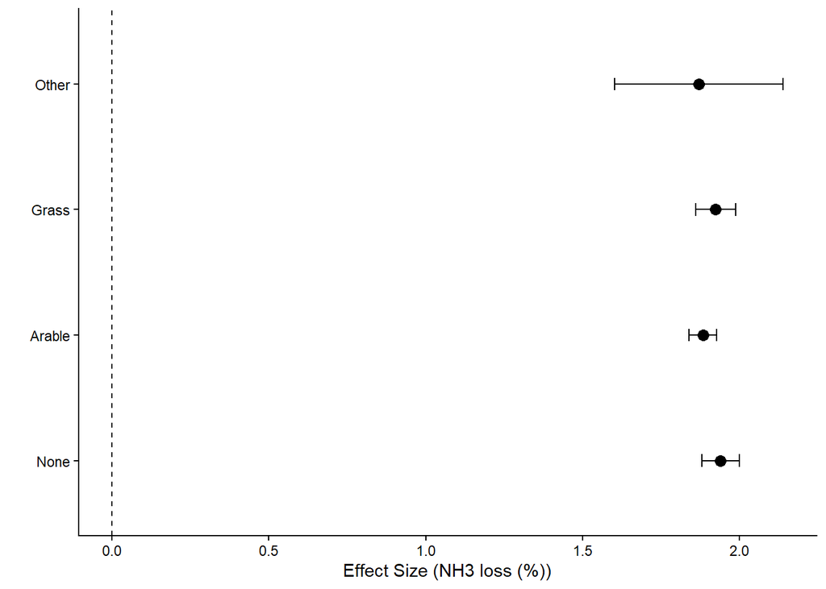

## Model A_Air temperature and rainfall

AirTemperature over the duration of the experiment (Celcius) and mean rainfall over the experimental period (mm) were analysed together, to explore interactions between the two variables. The frequency distributions of the two variables can be seen below.

There are 934 observations in the analysis.

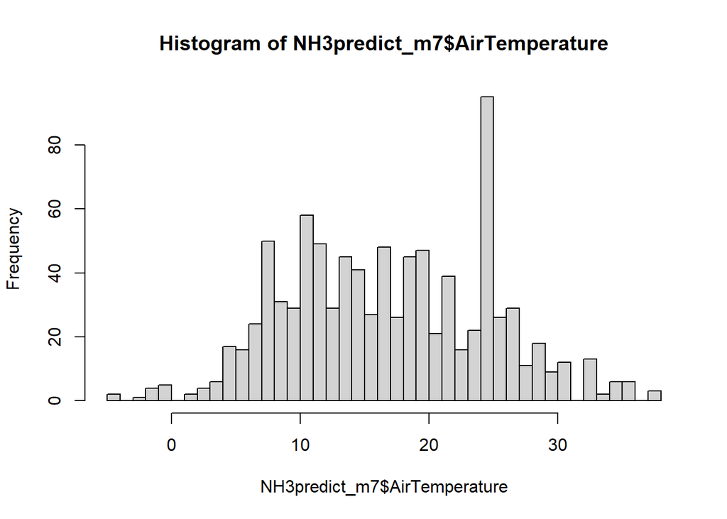

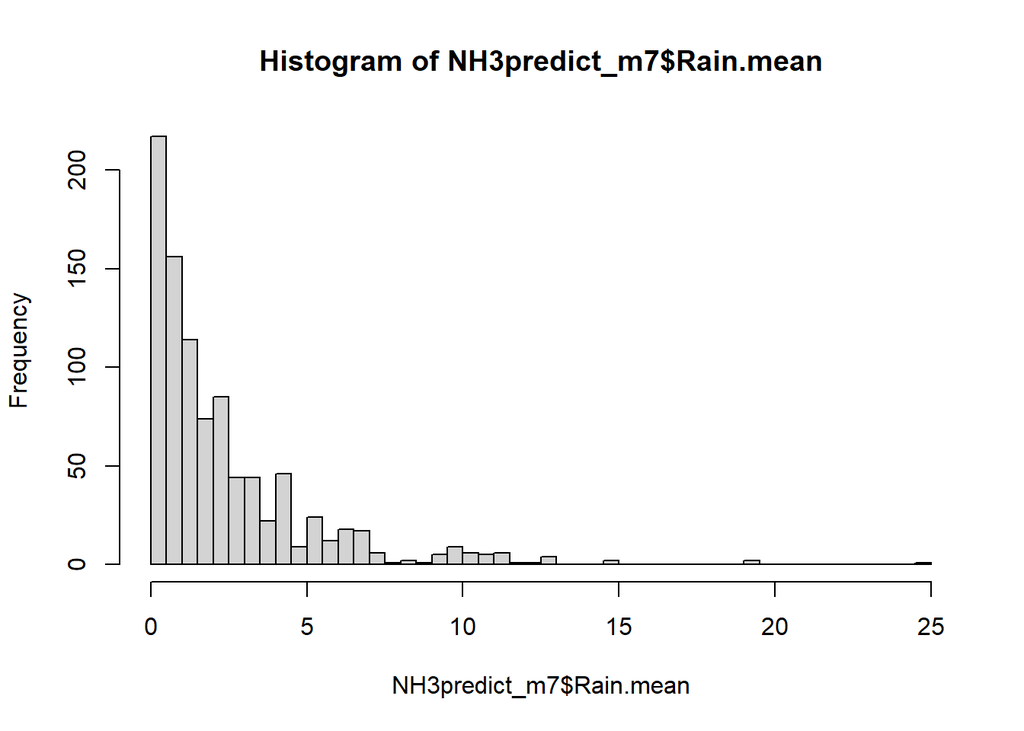

```r
# Model
mTR_lm <- lm(sign(NH3loss) * abs(NH3loss) ^ (1/3) ~ AirTemperature * Rain.mean + offset(M1_fit),
             weights=Weight,
             data=NH3predict_m7)
```

The model assumptions (heteroscedasticity and normality of errors):

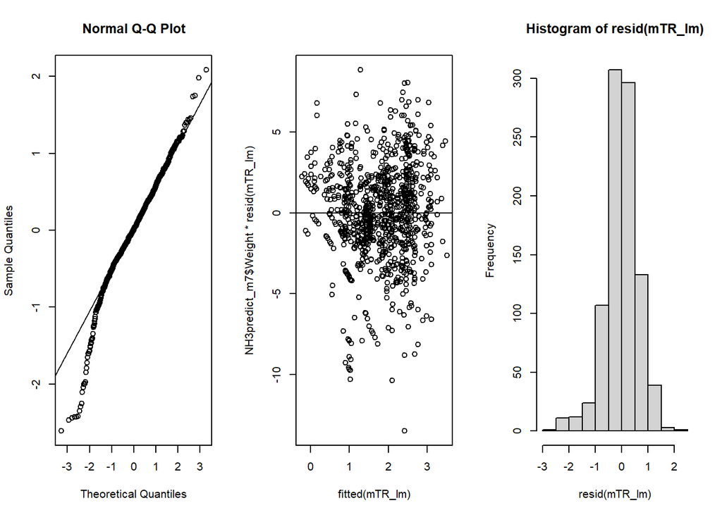

Full model output can be seen below:

```
##
## Call:
## lm(formula = sign(NH3loss) * abs(NH3loss)^(1/3) ~ AirTemperature *
##     Rain.mean + offset(M1_fit), data = NH3predict_m7, weights = Weight)
##
## Weighted Residuals:
##     Min      1Q  Median      3Q     Max
## -5.7169 -0.7327  0.0080  0.8576  4.2869
##
## Coefficients:
##                           Estimate Std. Error t value Pr(>|t|)
## (Intercept)              -0.021767   0.064759  -0.336   0.7369
## AirTemperature            0.004332   0.003512   1.233   0.2177
## Rain.mean                -0.058960   0.027239  -2.165   0.0307 *
## AirTemperature:Rain.mean  0.001764   0.001200   1.471   0.1417
## ---
## Signif. codes:  0 '***' 0.001 '**' 0.01 '*' 0.05 '.' 0.1 ' ' 1
##
## Residual standard error: 1.361 on 930 degrees of freedom
## Multiple R-squared:  0.01399,    Adjusted R-squared:  0.01081
## F-statistic: 4.397 on 3 and 930 DF,  p-value: 0.004413
```

Air temperature and rainfall, and the interaction between the two explain 1.08 % of the variation in the data.

The marginally non-significant interaction between rainfall and temperature can be interpreted as the slope of air temperature increasing in steepness with increasing rainfall. This means that the effect of temperature is dependent on rainfall, and temperature only has an effect when rain is present.

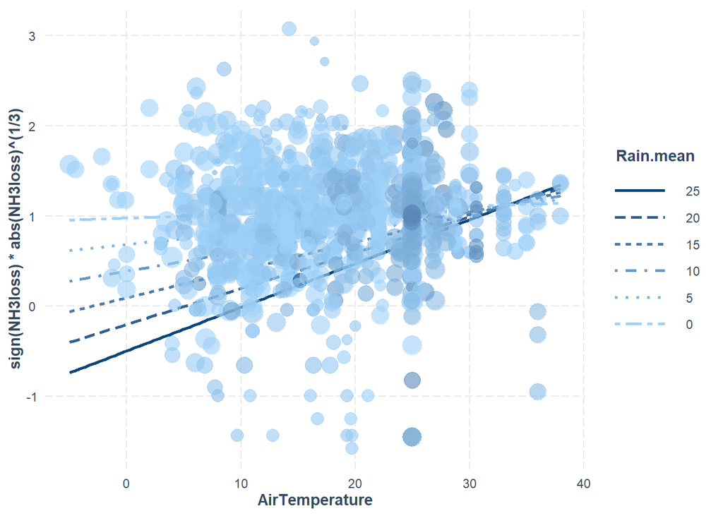

Similarly, the interaction can be interpreted from the perspective of rain: The association between rain and NH3 emissions changes from negative to slightly positive with increasing temperature.

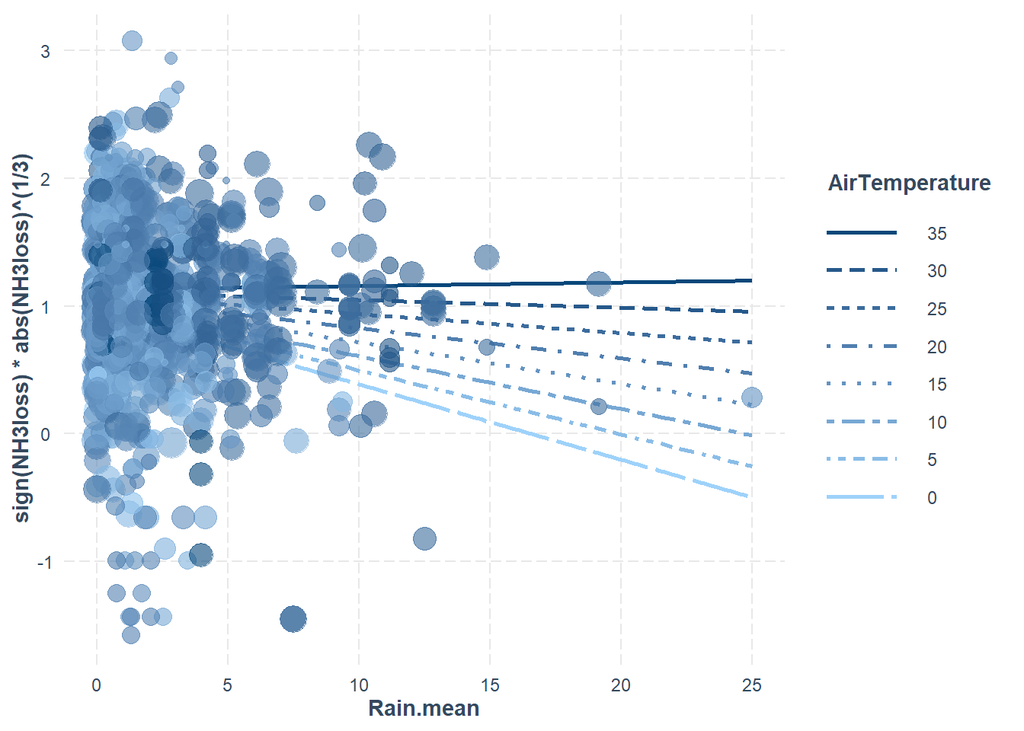

Simple slope analysis on the interaction can be seen below. The slope of temperature is statistically significant within range noted below. Note that the results below rely on statistical significance of the interaction in the model above, which is not fulfilled.

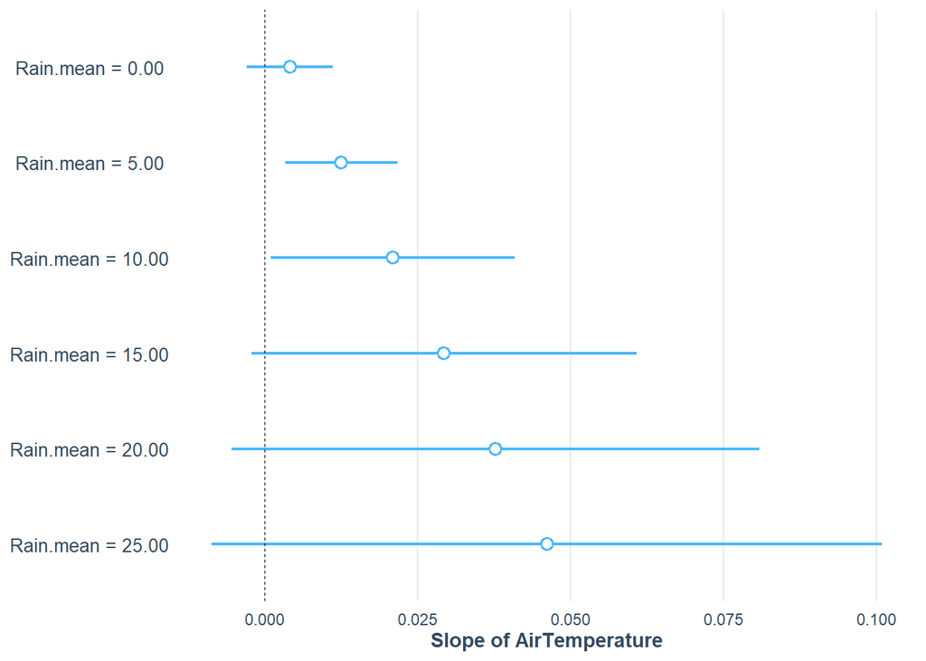

```
## JOHNSON-NEYMAN INTERVAL
##
## When Rain.mean is INSIDE the interval [0.86, 13.80], the slope of
## AirTemperature is p < .05.
##
## Note: The range of observed values of Rain.mean is [0.00, 25.00]
```

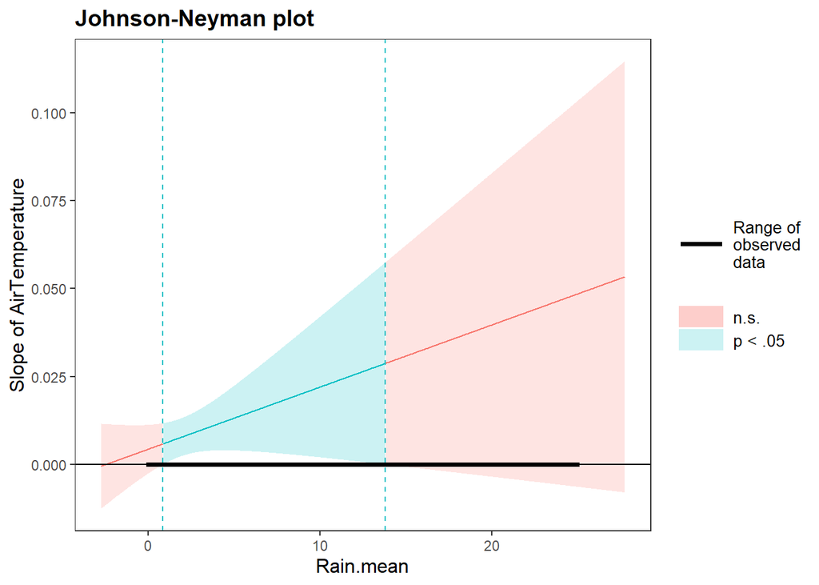

### A_Air temperature

Considering air temperature separately, there is a statistically significant effect of air temperature (F(1, 1045) =6.11, p = 0.014). Adjusted R2-value of the model was 0.00486, and multiple R2 was 0.00581. This means air temperature explains 0.486 % of the variation.

There are 1047 observations in the analysis.

The full model output with the slopes and their standard error can be seen below:

```
##
## Call:
## lm(formula = sign(NH3loss) * abs(NH3loss)^(1/3) ~ AirTemperature +
##     offset(M1_fit), data = NH3predict_m7_2, weights = Weight)
##
## Weighted Residuals:
##     Min      1Q  Median      3Q     Max
## -5.8873 -0.7135  0.0348  0.8271  4.3095
##
## Coefficients:
##                 Estimate Std. Error t value Pr(>|t|)
## (Intercept)    -0.102259   0.044932  -2.276   0.0231 *
## AirTemperature  0.005986   0.002422   2.472   0.0136 *
## ---
## Signif. codes:  0 '***' 0.001 '**' 0.01 '*' 0.05 '.' 0.1 ' ' 1
##
## Residual standard error: 1.334 on 1045 degrees of freedom
## Multiple R-squared:  0.005812,   Adjusted R-squared:  0.004861
## F-statistic: 6.109 on 1 and 1045 DF,  p-value: 0.01361
```

### A_Air temperature over first 7 days

There is no statistically significant effect of air temperature over the first 7 days of the experiment (F(1, 169) =1.58, p = 0.21). Adjusted R2-value of the model was 0.0034, and multiple R2 was 0.00926. This means air temperature over the first 7 days explains 0.34 % of the variation.

There are 171 observations in the analysis.

The full model output with the slopes and their standard error can be seen below:

```
##
## Call:
## lm(formula = sign(NH3loss) * abs(NH3loss)^(1/3) ~ Temp.7d + offset(M1_fit),
##     data = NH3predict_mA7, weights = Weight)
##
## Weighted Residuals:
##     Min      1Q  Median      3Q     Max
## -5.0217 -0.7041  0.3099  1.1309  3.2182
##
## Coefficients:
##             Estimate Std. Error t value Pr(>|t|)
## (Intercept)  0.15148    0.11796   1.284    0.201
## Temp.7d     -0.01008    0.00802  -1.257    0.210
##
## Residual standard error: 1.679 on 169 degrees of freedom
## Multiple R-squared:  0.009265,   Adjusted R-squared:  0.003403
## F-statistic:  1.58 on 1 and 169 DF,  p-value: 0.2104
```

### A_Mean daily rainfall

Considering mean rainfall separately, there is no statistically significant effect of rain (F(1, 1036) =2.57, p = 0.109). Adjusted R2-value of the model was 0.00151, and multiple R2 was 0.00248. Thus, rainfall doesn’t meaningfully explain any variation in the data.

There are 1038 observations in the analysis.

The full model output with the slopes and their standard error can be seen below:

```
##
## Call:
## lm(formula = sign(NH3loss) * abs(NH3loss)^(1/3) ~ Rain.mean +
##     offset(M1_fit), data = NH3predict_m8, weights = Weight)
##
## Weighted Residuals:
##     Min      1Q  Median      3Q     Max
## -5.6280 -0.7503  0.0427  0.8474  4.2586
##
## Coefficients:
##              Estimate Std. Error t value Pr(>|t|)
## (Intercept)  0.022978   0.024899   0.923    0.356
## Rain.mean   -0.011405   0.007113  -1.603    0.109
##
## Residual standard error: 1.346 on 1036 degrees of freedom
## Multiple R-squared:  0.002475,   Adjusted R-squared:  0.001512
## F-statistic: 2.571 on 1 and 1036 DF,  p-value: 0.1092
```

### A_Rainfall over first 72 h

There is no statistically significant effect of rainfall during the first 72h of the experiment (F(1, 671) =0.44, p = 0.51). Adjusted R2-value of the model was -8.4^{-4}, and multiple R2 was 6.5^{-4}. Thus, rainfall during the first 72h doesn’t meaningfully explain any variation in the data.

There are 673 observations in the analysis.

The full model output with the slopes and their standard error can be seen below:

```
##
## Call:
## lm(formula = sign(NH3loss) * abs(NH3loss)^(1/3) ~ Rain.72h +
##     offset(M1_fit), data = NH3predict_R8, weights = Weight)
##
## Weighted Residuals:
##     Min      1Q  Median      3Q     Max
## -5.7932 -0.7781  0.0665  0.8951  4.3258
##
## Coefficients:
##              Estimate Std. Error t value Pr(>|t|)
## (Intercept)  0.007491   0.027530   0.272    0.786
## Rain.72h    -0.001089   0.001650  -0.660    0.510
##
## Residual standard error: 1.439 on 671 degrees of freedom
## Multiple R-squared:  0.0006486,  Adjusted R-squared:  -0.0008408
## F-statistic: 0.4355 on 1 and 671 DF,  p-value: 0.5095
```

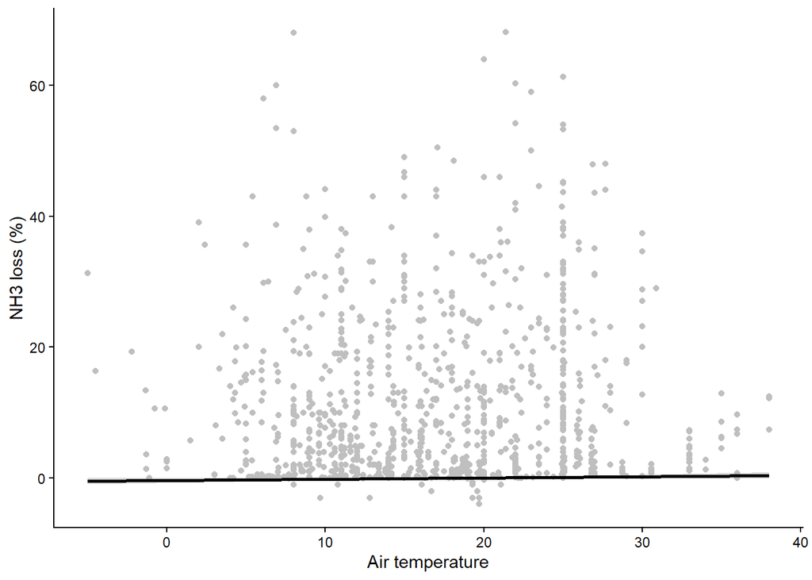

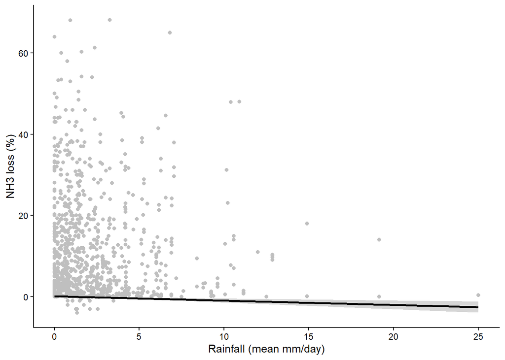

### A_Rainfall as a non-linear effect

We fitted an exponential function with parameters a and b to rainfall data. The equation is as follows:

$f(Rain.mean) = a * e^{(b*Rain.mean)}$

To test the fit and to estimate parameters a and b, we fitted a non-linear least-squares model.

```
##
## Formula: NH3loss ~ a * exp(b * (Rain.mean))
##
## Parameters:
##   Estimate Std. Error t value Pr(>|t|)
## a 11.57340    0.58608   19.75   <2e-16 ***
## b -0.03525    0.01727   -2.04   0.0416 *
## ---
## Signif. codes:  0 '***' 0.001 '**' 0.01 '*' 0.05 '.' 0.1 ' ' 1
##
## Residual standard error: 12.57 on 932 degrees of freedom
##
## Number of iterations to convergence: 12
## Achieved convergence tolerance: 1.49e-08
```

The fitted relationship is as below:

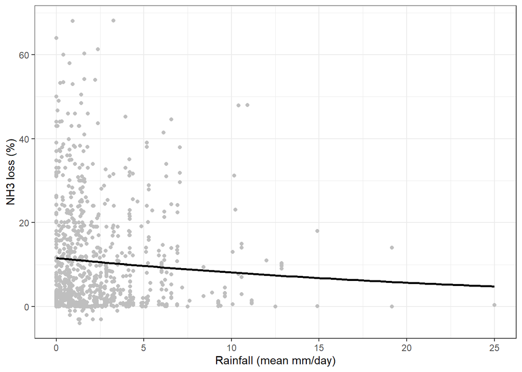

The RMSE (root mean square error) of the model was 12.5526708, which is on the same scale as mean NH3loss values in the data (10.7023381) indicating a poor fit of the model. (Error equal to the estimated value.)

We calculated new rain estimates on the exponential scale, with the estimated parameters taken into account, and ran the analysis with air temperature again, using the exponential Rain.mean values calculated using the coefficients (parameter estimates) from the non-linear least-squares fit above.

```r
# Transforming the Rain values to exp-scale
NH3predict_m7$Rain.exp <- coef(MR_nls)[[1]]*exp(coef(MR_nls)[[2]]*NH3predict_m7$Rain.mean)
```

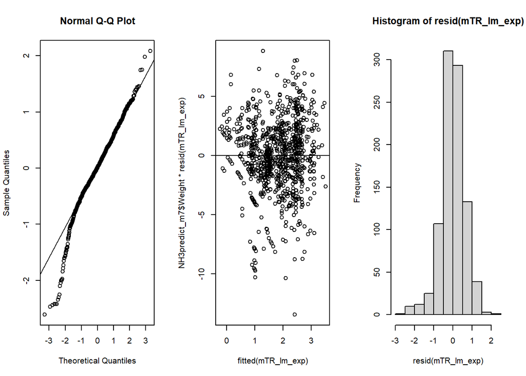

```
##
## Call:
## lm(formula = sign(NH3loss) * abs(NH3loss)^(1/3) ~ AirTemperature *
##     Rain.exp + offset(M1_fit), data = NH3predict_m7, weights = Weight)
##
## Weighted Residuals:
##     Min      1Q  Median      3Q     Max
## -5.7065 -0.7312  0.0089  0.8584  4.2888
##
## Coefficients:
##                          Estimate Std. Error t value Pr(>|t|)
## (Intercept)             -1.905244   0.846570  -2.251   0.0246 *
## AirTemperature           0.059034   0.037250   1.585   0.1134
## Rain.exp                 0.163142   0.076907   2.121   0.0342 *
## AirTemperature:Rain.exp -0.004724   0.003418  -1.382   0.1672
## ---
## Signif. codes:  0 '***' 0.001 '**' 0.01 '*' 0.05 '.' 0.1 ' ' 1
##
## Residual standard error: 1.361 on 930 degrees of freedom
## Multiple R-squared:  0.01391,    Adjusted R-squared:  0.01073
## F-statistic: 4.374 on 3 and 930 DF,  p-value: 0.004559
```

```
##
## Call:
## lm(formula = sign(NH3loss) * abs(NH3loss)^(1/3) ~ AirTemperature +
##     Rain.exp + offset(M1_fit), data = NH3predict_m7, weights = Weight)
##
## Weighted Residuals:
##     Min      1Q  Median      3Q     Max
## -5.6471 -0.7374 -0.0008  0.8562  4.2837
##
## Coefficients:
##                 Estimate Std. Error t value Pr(>|t|)
## (Intercept)    -0.795298   0.268433  -2.963  0.00313 **
## AirTemperature  0.007680   0.002748   2.795  0.00530 **
## Rain.exp        0.061770   0.023186   2.664  0.00785 **
## ---
## Signif. codes:  0 '***' 0.001 '**' 0.01 '*' 0.05 '.' 0.1 ' ' 1
##
## Residual standard error: 1.362 on 931 degrees of freedom
## Multiple R-squared:  0.01189,    Adjusted R-squared:  0.009763
## F-statistic:   5.6 on 2 and 931 DF,  p-value: 0.003825
```

When non-linear rain is analysed separately, there is no effect of rain on NH3loss (F(1, 1036) =2.49, p = 0.115). See the slope estimate from below:

```
##
## Call:
## lm(formula = sign(NH3loss) * abs(NH3loss)^(1/3) ~ Rain.exp +
##     offset(M1_fit), data = NH3predict_m8, weights = Weight)
##
## Weighted Residuals:
##     Min      1Q  Median      3Q     Max
## -5.6254 -0.7508  0.0438  0.8442  4.2592
##
## Coefficients:
##             Estimate Std. Error t value Pr(>|t|)
## (Intercept) -0.35664    0.22498  -1.585    0.113
## Rain.exp     0.03298    0.02090   1.577    0.115
##
## Residual standard error: 1.346 on 1036 degrees of freedom
## Multiple R-squared:  0.002396,   Adjusted R-squared:  0.001433
## F-statistic: 2.488 on 1 and 1036 DF,  p-value: 0.115
```